# Covid-19 In Connecticut and the USA, September 1, 2020

Andrew F. Griffin

9/01/2020

### CONNECTICUT

**NEW REPORTS FOR TODAY, YESTERDAY, LAST WEEK, AND LAST MONTH**

| DATE | STATE | NEW CASES | NEW TESTS | PERCENT POSITIVE | NEW DEATHS |
| --- | --- | --- | --- | --- | --- |
| 2020-09-01 | CT | 127 | 19,242 | 0.7 | 1 |
| 2020-08-31 | CT | 384 | 45,590 | 0.8 | 0 |
| 2020-08-25 | CT | 29 | 4,990 | 0.6 | 3 |
| 2020-08-04 | CT | 48 | 7,089 | 0.7 | 0 |

Note:  
Data From the Covid Tracking Project  
Connecticut no longer reports on weekends

**TOTALS PER 100K PEOPLE OVER THE LAST 7 DAYS**

| STATE | SUM NEW CASES PER CAPITA | SUM NEW TESTS PER CAPITA | SUM NEW DEATHS PER CAPITA |
| --- | --- | --- | --- |
| CT | 27.9 | 3,208 | 0.168 |

Note:  
Data From the Covid Tracking Project  
Connecticut no longer reports on weekends

As I had hoped, Connecticut testing surged in today’s reporting. Today’s reporting was Connecticut’s highest new test volume for a Tuesday in over six weeks by more than 9,000 tests. I think you could argue that this is a good first sign to come out of the Connecticut colleges reopening story is the priority there currently seems to be on testing.

While, New Cases had recently been on the rise, they seem to be tapering off a bit. This hadn’t been linked to any colleges, and the biggest problem had been in the city of Danbury (John Oliver must have been onto something). That said, it’s worth keeping an eye on.

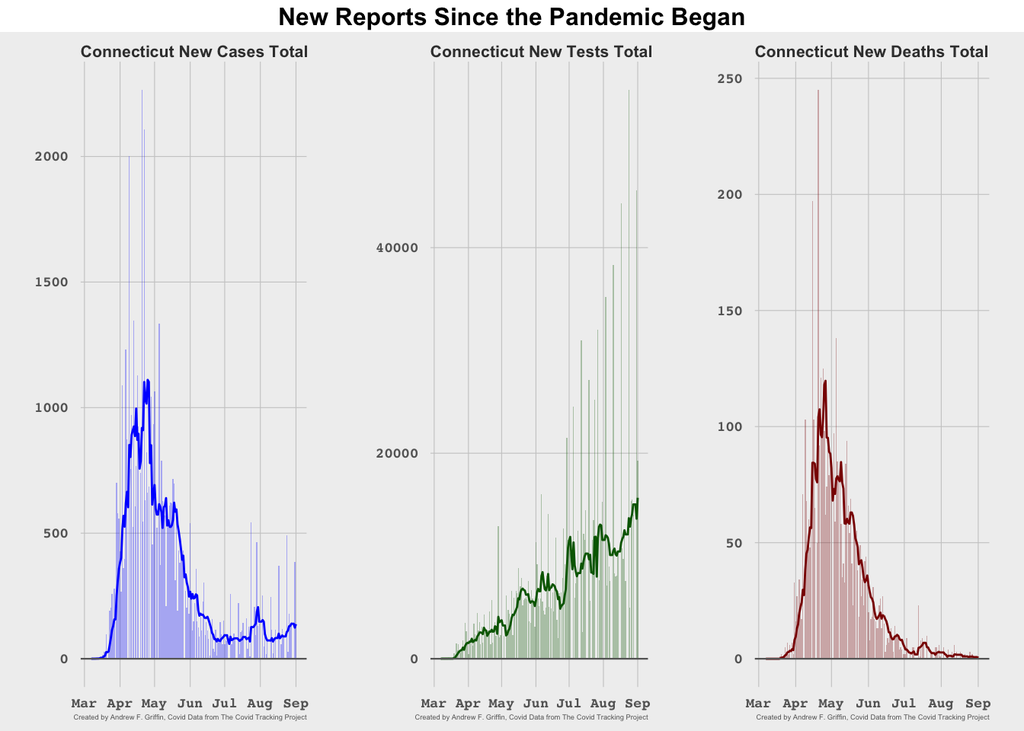

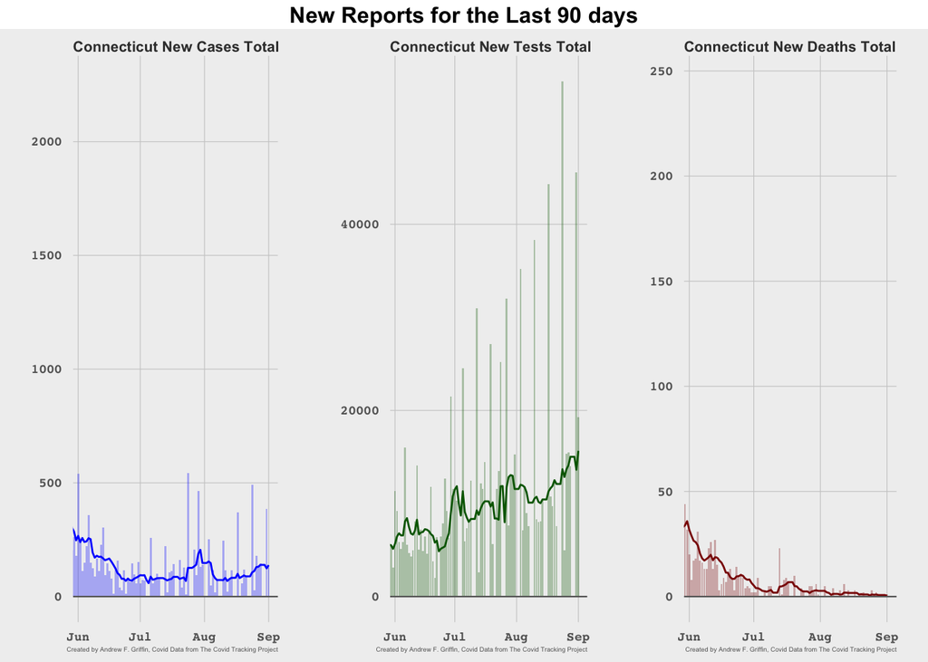

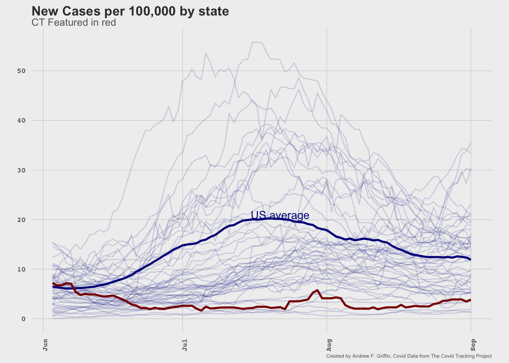

### THE USA

**UNITED STATES TOTAL NEW REPORTS FOR TODAY, YESTERDAY, LAST WEEK, AND LAST MONTH**

| DATE | NEW CASES | NEW TESTS | PERCENT POSITIVE | NEW DEATHS |
| --- | --- | --- | --- | --- |
| 2020-09-01 | 42,343 | 703,354 | 6.0 | 1,018 |
| 2020-08-31 | 31,353 | 685,072 | 4.6 | 358 |
| 2020-08-25 | 36,283 | 644,505 | 5.6 | 1,146 |
| 2020-08-04 | 51,834 | 716,376 | 7.2 | 1,255 |

Note:  
Data From the Covid Tracking Project

**7 DAY UNITED STATES TOTALS**

| TOTAL NEW CASES | TOTAL NEW TESTS | TOTAL NEW DEATHS |
| --- | --- | --- |
| 327,369 | 5,740,010 | 7,457 |

Note:  
Data From the Covid Tracking Project

For now though, the good news is that new deaths are notonly under 1,000 a day, but they are trending downward. This is could be a signal that the tail end of what has been wave two may be bringing those numbers back down. Deaths tend to be a bit of a lagging indicator.

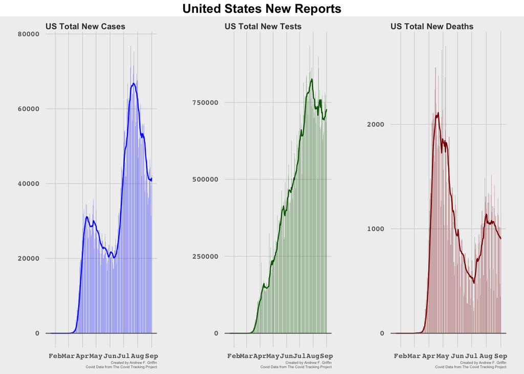

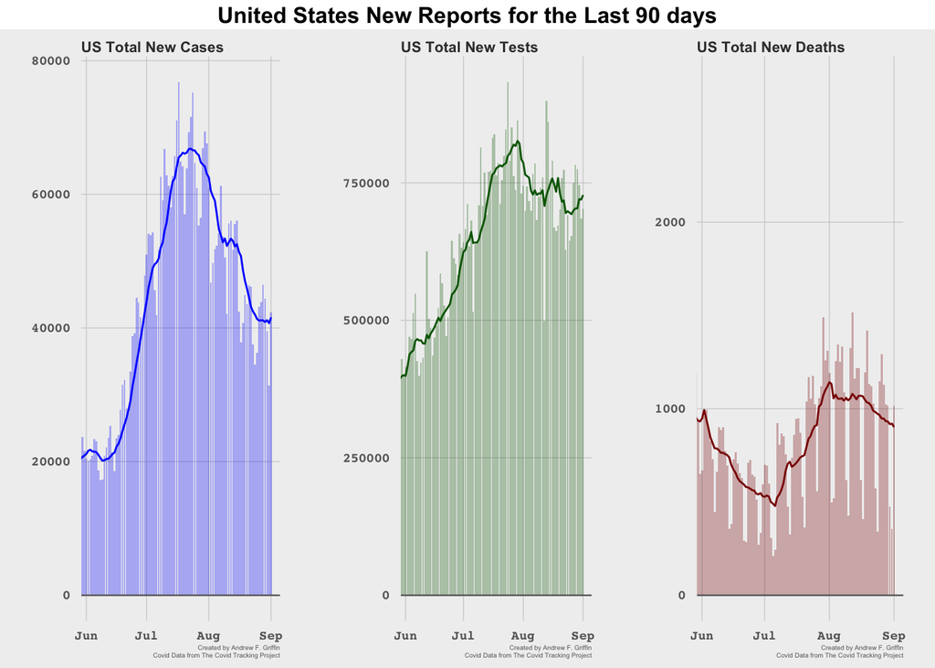

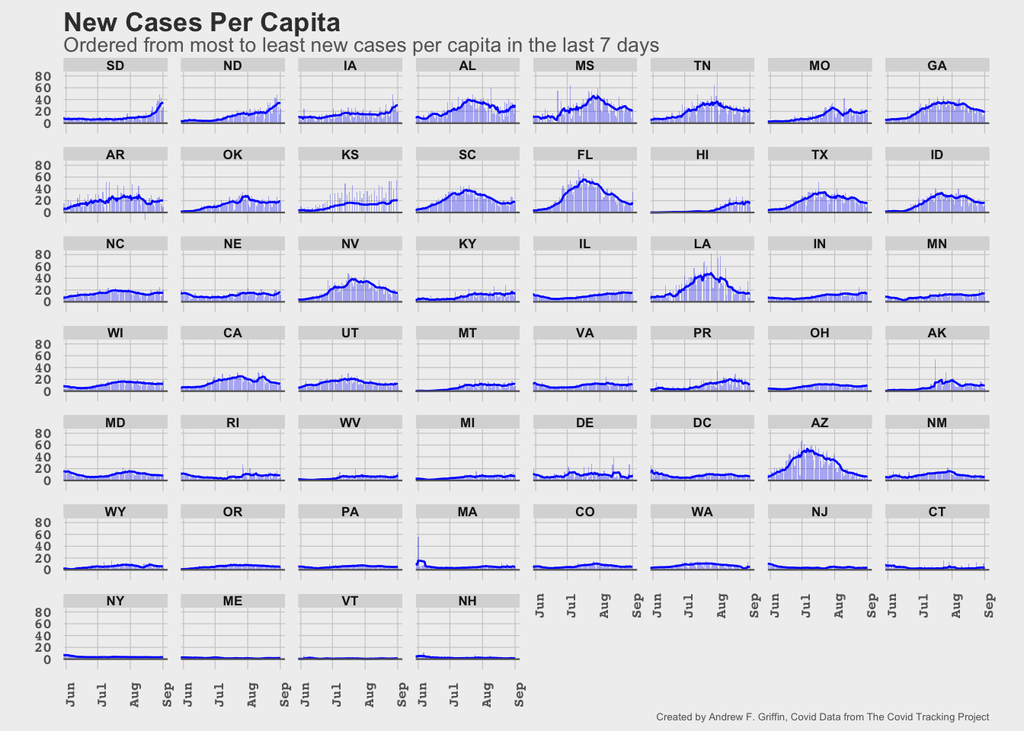

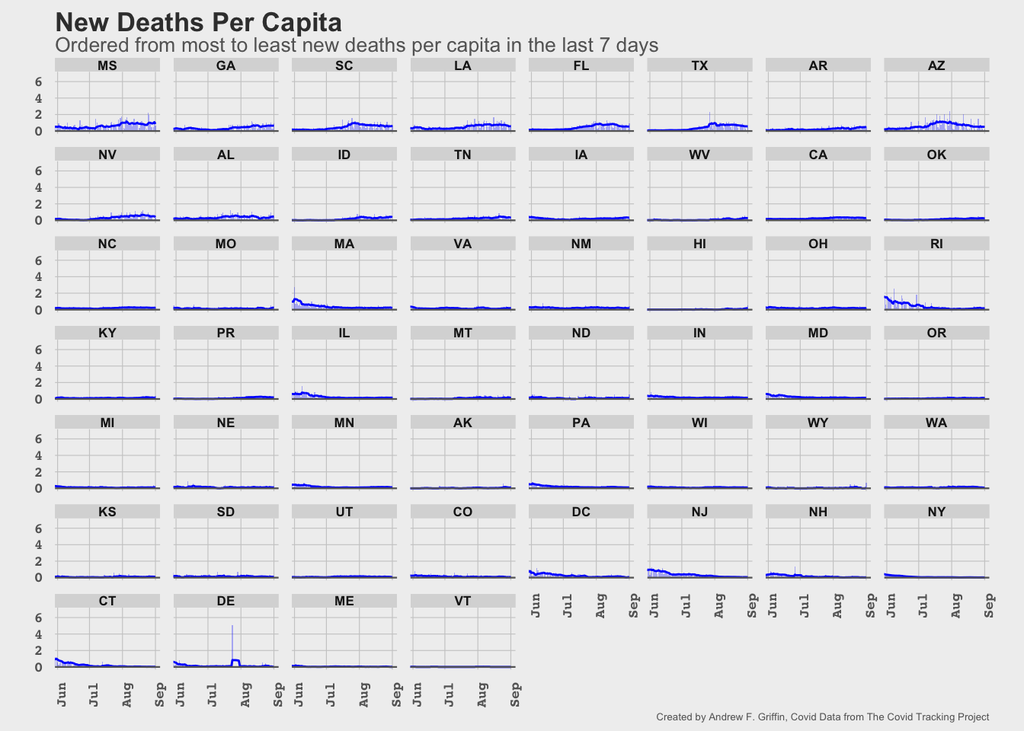